# Non-Parametric Statistics Assignment3

# 课后题

## 1.10

考虑一个从参数$\lambda = 1$的指数分布中抽取的容量为100的样本

- (1)给出样本的`对数经验生存函数`$lnS_n(t)$的`标准差`。($lnS_n(t)$作为t的函数)
- (2)从计算机中产生几个类似的`容量为100`的样本，画出他们的`对数经验生存函数图`，联系图补充对(1)的回答

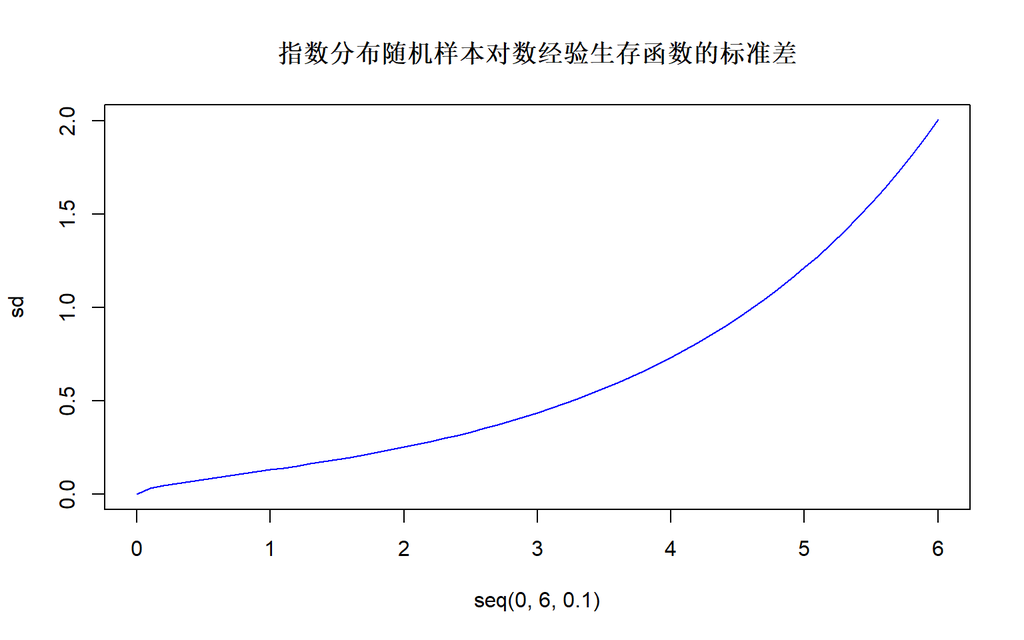

```r
size = 100
# 根据计算公式，直接算出对数经验生存函数的方差
var = pexp(seq(0, 6, 0.1), 1) / (1-pexp(seq(0, 6, 0.1), 1)) / size
# 计算标准差
sd = sqrt(var)
# 画图
plot(seq(0, 6, 0.1), sd, type = 'l', col = 'blue', main = '指数分布随机样本对数经验生存函数的标准差')
```

下面是对经验分布、经验生存、对数经验生存的基本可视化。

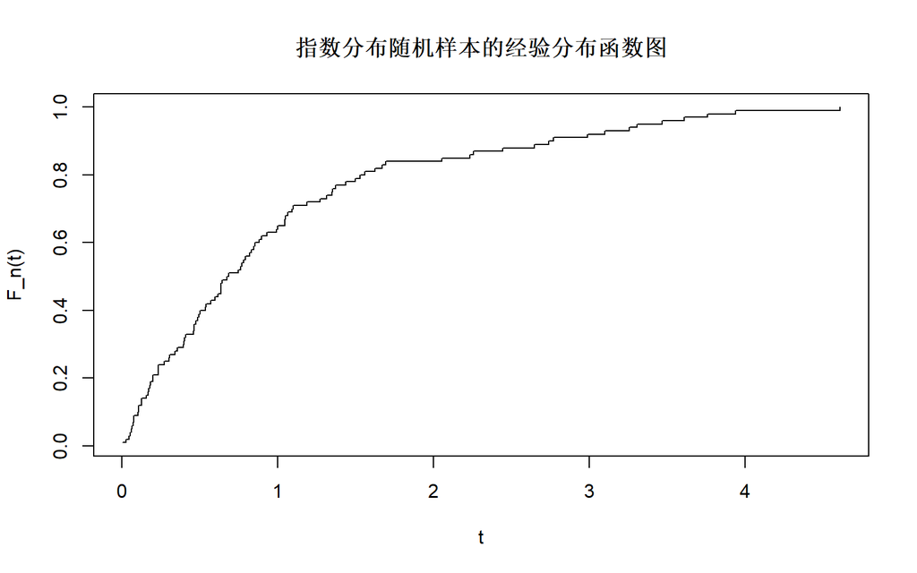

```r
size = 100
data = rexp(size, 1)
data.sort = sort(data)
data.rank = rank(data.sort)
data.cdf = data.rank / length(data)


# 经验分布
plot(data.sort, data.cdf, type = 's', main = '指数分布随机样本的经验分布函数图', xlab = 't', ylab = 'F_n(t)')
```

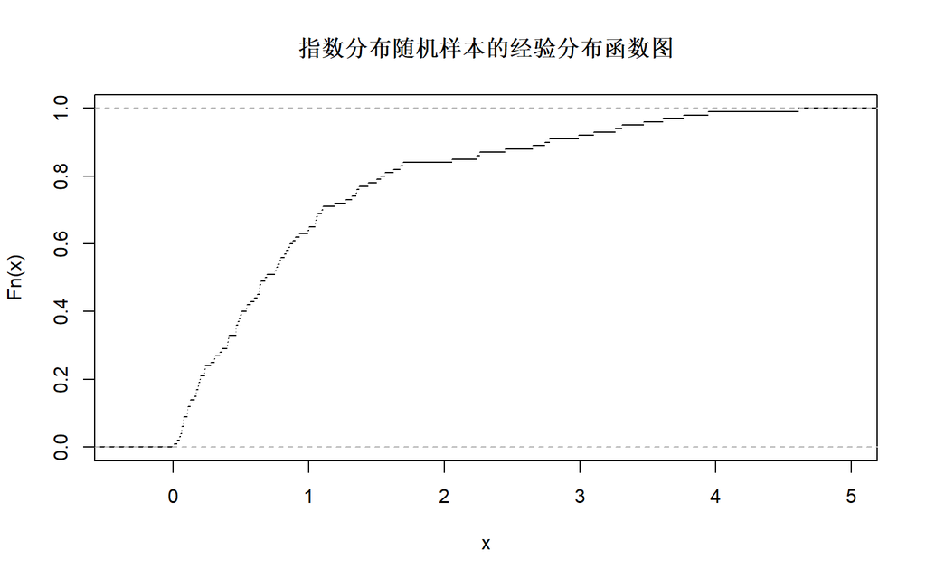

```r
#经验分布的另一种画法
plot.ecdf(data, do.points = FALSE, verticals = FALSE, main = '指数分布随机样本的经验分布函数图')
```

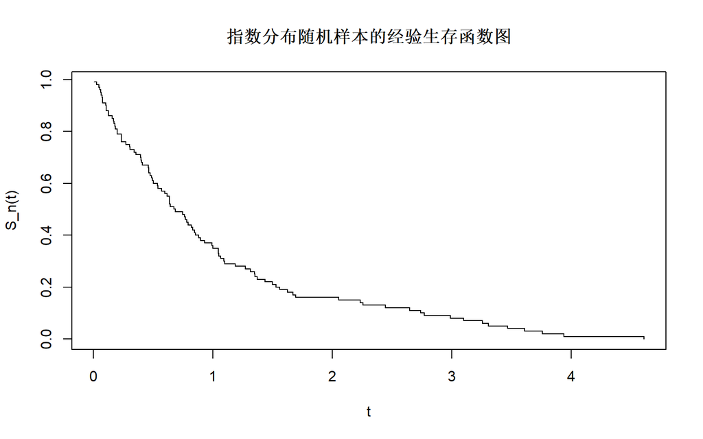

```r
# 经验生存
plot(data.sort, 1 - data.cdf, type = 's', main = '指数分布随机样本的经验生存函数图', xlab = 't', ylab = 'S_n(t)')
```

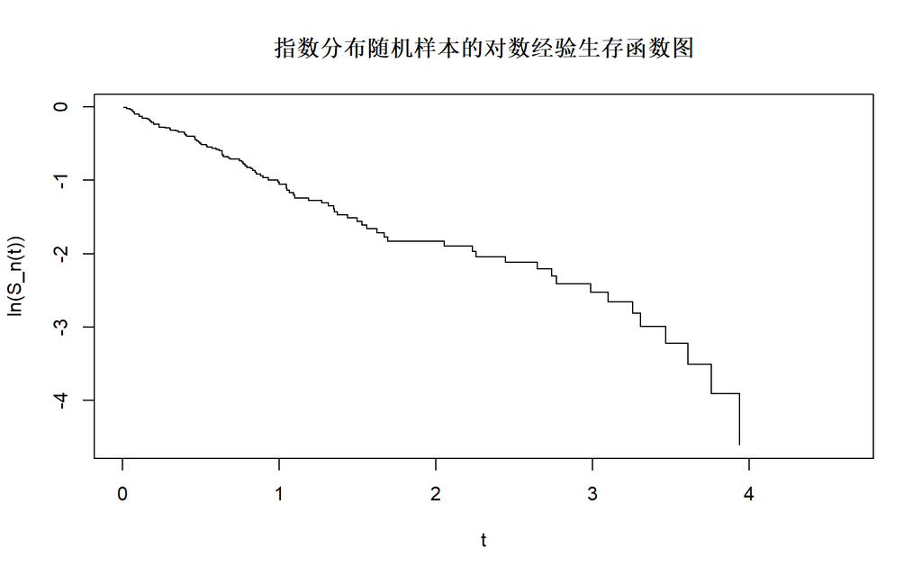

```r
# 对数经验生存
plot(data.sort, log(1 - data.cdf), type = 's', main = '指数分布随机样本的对数经验生存函数图', xlab = 't', ylab = 'ln(S_n(t))')
```

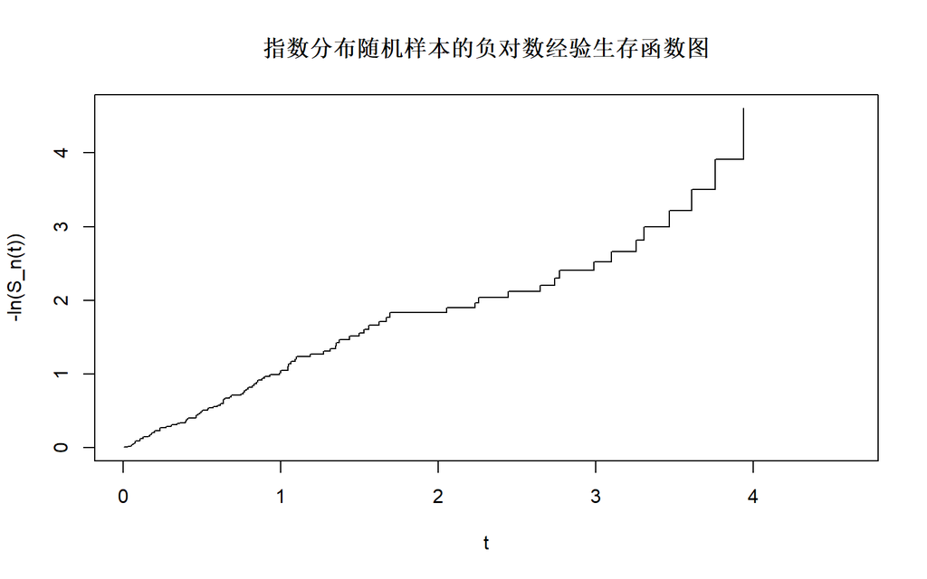

```r
# 负对数经验生存
plot(data.sort, -log(1 - data.cdf), type = 's', main = '指数分布随机样本的负对数经验生存函数图', xlab = 't', ylab = '-ln(S_n(t))')
```

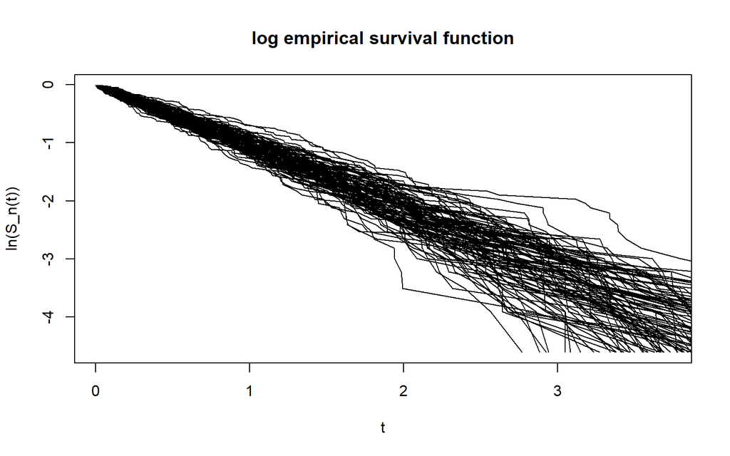

```r
# 编写函数simulate画groups条，样本量为size的对数经验生存函数
simulate = function(groups, size){
  data = rexp(size, 1)
  data.sort = sort(data)
  data.rank = rank(data.sort)
  data.cdf = data.rank / length(data)
  plot(data.sort, log(1 - data.cdf), type = 'l', lty = 1, main = 'log empirical survival function', xlab = 't', ylab = 'ln(S_n(t))')

  for(i in 2:groups){
    data = rexp(size, 1)
    data.sort = sort(data)
    data.rank = rank(data.sort)
    data.cdf = data.rank / length(data)
    lines(data.sort, log(1 - data.cdf), type = 'l', lty = 1)
  }
}
# 样本量100，画100组实验
simulate(100, 100)
```

很明显，经验生存函数的标准差，方差随着时间增加单调增大。这和(1)中直接计算得到的答案是吻合的。

## 1.12

考虑一个实验：对减轻皮肤瘙痒的药物进行疗效研究(Beecher,1959)。在10名20-30岁的男性志愿者身上做实验比较`五种药物`和`安慰剂`、`无药`的效果。

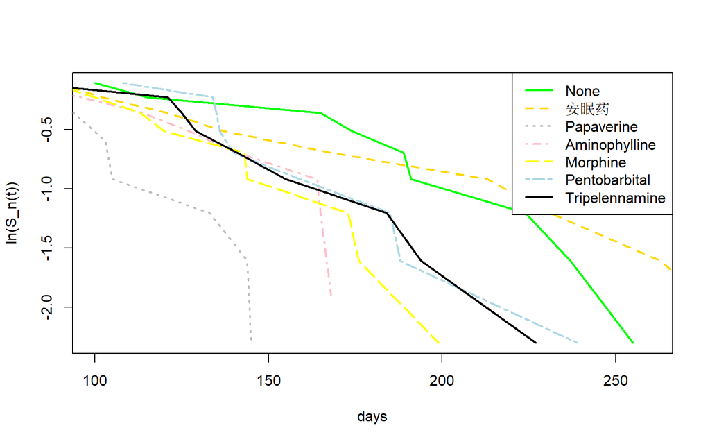

```r
# 数据加载
skin_data = read.csv('E:\\大三上\\Non-Parametric Statistics 王星\\Week3\\skin.csv', header = TRUE)

# 绘制各组的经验生存函数
plot(sort(skin_data$无药), log(1 - rank(sort(skin_data$无药)) / nrow(skin_data)), type = 'l', lty = 1, lwd = 2, col = 'green', xlab = "days", ylab = "ln(S_n(t))")
lines(sort(skin_data$安慰剂), log(1 - rank(sort(skin_data$安慰剂)) / nrow(skin_data)), type = 'l', lty = 2, lwd = 2, col = 'gold')


lines(sort(skin_data$Papaverine), log(1 - rank(sort(skin_data$Papaverine)) / nrow(skin_data)), type = 'l', lty = 3, lwd = 2, col = 'grey')
lines(sort(skin_data$Aminophylline), log(1 - rank(sort(skin_data$Aminophylline)) / nrow(skin_data)), type = 'l', lty = 4, lwd = 2, col = 'pink')
lines(sort(skin_data$Morphine), log(1 - rank(sort(skin_data$Morphine)) / nrow(skin_data)), type = 'l', lty = 5, lwd = 2, col = 'yellow')
lines(sort(skin_data$Pentobarbital), log(1 - rank(sort(skin_data$Pentobarbital)) / nrow(skin_data)), type = 'l', lty = 6, lwd = 2, col = 'lightblue')
lines(sort(skin_data$Tripelennamine), log(1 - rank(sort(skin_data$Tripelennamine)) / nrow(skin_data)), type = 'l', lty = 7, lwd = 2, col = 'black')
legend("topright", lty = 1:7, lwd = rep(2, 7), legend = c("None", "安眠药", "Papaverine", "Aminophylline", "Morphine", "Pentobarbital", "Tripelennamine"), col = c('green', 'gold', 'grey', 'pink', 'yellow', 'lightblue', 'black'))
```

# 思考题

## 一、分布函数

思考什么变量的分布函数满足经验分布
$$\hat F_n(x) = \frac{1}{n}\sum_{i=1}^n I(x_i \leqslant x)$$
设离散型随机变量y, $y \in\{x_1,x_2,...x_n\}$ 且 $P\{y=x_i\}=\frac{1}{n},i=1,2,...,n$ 其有分布函数
$$F(x)=\left\{
\begin{array}{1}
\begin{aligned}
1 &,& x\geqslant x_{(n)} \\
\frac{i}{n} &,& x_{(i)} \leqslant x < x_{(i+1)}\\
0 &,& x < x_{(1)}
\end{aligned}
\end{array}
\right.$$
与$\hat F_n(x)$的一致。

## 二、Neyman-Pearson

讨论引理中$f=f_0$的情况

根据定义，两个拒绝域$W_\alpha, W'\in X$一个尺度为$\alpha$，另一个水平为$\alpha$，即满足$P\{x\in W_\alpha\}=\alpha, P\{x\in W'\}\leqslant\alpha,$

事实上，$\int_{W_\alpha} f_0(x)dx=P\{x\in W_\alpha | \theta \in \theta_0\}=\alpha$

并且，$\int_{W'} f_0(x)dx=P\{x\in W' | \theta \in \theta_0\}\leqslant \alpha$

自然得到了 $\int_{W_\alpha} f_0(x)dx \geqslant \int_{W'} f_0(x)dx$